# Sustained improved survival of patients with metastatic melanoma after the introduction of anti-PD-1-based therapies

¶ Descriptive and survival analyses, tables & figures for paper ¶

Aimilia Schina

First created on May 2022. Updated on 28 December 2023

```r
RNGkind(sample.kind = "Rounding")
## Clear R-workspace
rm(list=ls(all=TRUE))

## Close all graphic devices
graphics.off()
#####################
### Load packages ###
#####################
library(pacman)
pacman::p_load(extrafont,DT, dplyr,data.table, tibble,dataMaid, Amelia,
               ggplot2,ggpubr,survival,
               gtsummary,forcats,ggstatsplot,ezfun, officer,
               flextable,readxl,cowplot,hrbrthemes,ggrepel,survminer, stringr,ggpmisc,patchwork,ggsci,tidyverse,gridExtra)
other_pckgs <- c("lubridate", "scales")
require(other_pckgs)

###########################

windowsFonts(Palatino=windowsFont("Palatino"))

extrafont::loadfonts(device="win")
windowsFonts(`Palatino`="Palatino")
loadfonts(device="win")
loadfonts(device="postscript")
```

```r
###########################
### Main analysis paths ###
###########################

scriptsPath <- paste0("scripts/")
scriptsFunctionsPath <- paste0(scriptsPath,"functions/")
projectDataPath <- paste0("data/")
projectOutDataPath <- paste0("output/data_files/")
figuresPath <- paste0("output/figures/")
tablesPath <- paste0("output/tables/")
sessionInfoPath <- paste0("session_info/")


##################################
### LOAD SOURCE FUNCTIONS FILE ###
##################################
source(paste0(scriptsFunctionsPath,"data_preprocessing_functions.R"))

#####################
### File suffixes ###
#####################
Rdata.suffix <- ".RData"
```

# 1 Data

## 1.1 Loading merged document

```r
dataDF.new <- read_excel(paste0(projectDataPath, "MERGED_27022023.xlsx")) %>% as.data.frame()


table(dataDF.new$`Year of diagnosis`)
```

```
##
## 2012 2014 2016 2018
##  241  284  313  325
```

```r
table(dataDF.new$`Year of diagnosis`, dataDF.new$firstLine)
```

```
##
##        Anti-CTLA-4 Anti-PD-1 Anti-PD-1 plus Anti-CTLA-4 BRAFi
##   2012          26         0                          0    14
##   2014         136         1                          1    44
##   2016           1       149                         11    67
##   2018           1       157                         79    49
##
##        Experimental Treatments IFN/IL2 IL2 intralesional No treatment
##   2012                       0      58                 0           73
##   2014                       1       1                 0           62
##   2016                       8       1                 0           68
##   2018                       4       0                 1           34
##
##        Temozolomid
##   2012          70
##   2014          38
##   2016           8
##   2018           0
```

```r
table(dataDF.new$linje1_v2,dataDF.new$firstLine)
```

```
##
##                                            Anti-CTLA-4 Anti-PD-1
##   BMS 047 Nivolumab/LAG3                             0         0
##   BMS 511                                            0         0
##   BMS 511 Ipi(3)/Nivo(1) vs Ipi(1)/Nivo(3)           0         0
##   BRAF/MEK inhib                                     0         0
##   COMBI-V                                            0         0
##   Dabrafenib/Trametinib                              0         0
##   Eksperimental i Tyskland                           0         0
##   IFN/IL2                                            0         0
##   IL-2 intralesional                                 0         0
##   Ipilimumab                                       128         0
##   Ipilimumab-IDO                                    10         0
##   Ipilimumab (3vs10)                                26         0
##   Ipilimumab Nivolumab                               0         0
##   KN 022 Dabra/Tram +/- Pembro                       0         0
##   KN 252 Pembro +/- Epacadostat                      0        11
##   Nivolumab PD-L1/IDO                                0        12
##   NULL                                               0         0
##   Pembrolizumab                                      0       284
##   T-celler                                           0         0
##   Temozolomid                                        0         0
##   Vemurafenib/Cobimetinib                            0         0
##
##                                            Anti-PD-1 plus Anti-CTLA-4 BRAFi
##   BMS 047 Nivolumab/LAG3                                            0     0
##   BMS 511                                                          10     0
##   BMS 511 Ipi(3)/Nivo(1) vs Ipi(1)/Nivo(3)                          1     0
##   BRAF/MEK inhib                                                    0    49
##   COMBI-V                                                           0     2
##   Dabrafenib/Trametinib                                             0   104
##   Eksperimental i Tyskland                                          0     0
##   IFN/IL2                                                           0     0
##   IL-2 intralesional                                                0     0
##   Ipilimumab                                                        0     0
##   Ipilimumab-IDO                                                    0     0
##   Ipilimumab (3vs10)                                                0     0
##   Ipilimumab Nivolumab                                             80     0
##   KN 022 Dabra/Tram +/- Pembro                                      0     0
##   KN 252 Pembro +/- Epacadostat                                     0     0
```

[output cut: 60 more lines]

```
##   Eksperimental i Tyskland                           0
##   IFN/IL2                                            0
##   IL-2 intralesional                                 0
##   Ipilimumab                                         0
##   Ipilimumab-IDO                                     0
##   Ipilimumab (3vs10)                                 0
##   Ipilimumab Nivolumab                               0
##   KN 022 Dabra/Tram +/- Pembro                       0
##   KN 252 Pembro +/- Epacadostat                      0
##   Nivolumab PD-L1/IDO                                0
##   NULL                                               0
##   Pembrolizumab                                      0
##   T-celler                                           0
##   Temozolomid                                      116
##   Vemurafenib/Cobimetinib                            0
```

```r
table(dataDF.new$firstLine)
```

```
##
##                Anti-CTLA-4                  Anti-PD-1
##                        164                        307
## Anti-PD-1 plus Anti-CTLA-4                      BRAFi
##                         91                        174
##    Experimental Treatments                    IFN/IL2
##                         13                         60
##          IL2 intralesional               No treatment
##                          1                        237
##                Temozolomid
##                        116
```

Total of patients used for the project: 1163`

```r
datatable(dataDF.new %>% dplyr::filter(firstLine %in% c("Experimental Treatments")) %>% droplevels(), extensions = 'Buttons', options = list(
    dom = 'Bfrtip',
    buttons = c('copy', 'excel', 'csv' ),
    scrollX=TRUE,
    pageLength=15
  ),
  caption = 'Patient data, experimental treatments'
)
```

### 1.1.1 Data with missing values in all parameters

```r
# Fix the brainmets (will include NAs)and BRAIN (will not include NAs-all unknown are marked as no) columns
dataDF.new<-dataDF.new %>% add_column(`brainmets_final`= ifelse(dataDF.new$brainmets %in% c("Yes - not active metastases","Yes - active metastases","Yes"),"yes",
                                     ifelse(dataDF.new$brainmets %in% c("No metastases","No"),"no",NA)), .after ="brainmets" )

# Replace BRAIN with correct
dataDF.new$BRAIN <- ifelse(is.na(dataDF.new$brainmets_final),"no",dataDF.new$brainmets_final) # FOR ELIGIBILITY, eliminates NAs

dataDF.new$PS <- ifelse(dataDF.new$PS %in% c("YES","Yes","yes"),"yes", "no") # FOR ELIGIBILITY, eliminates NAs

dataDF.new$Steroids <- ifelse(dataDF.new$Steroids %in% c("YES","Yes","yes"),"yes", "no") # IN GENERAL ALL NAs ASSIGNED TO NO

dataDF.new$Comorbidities <- ifelse(dataDF.new$Comorbidities %in% c("YES","Yes","yes"),"yes",
                        ifelse(dataDF.new$Comorbidities %in% c("NO","No","no"),"no",NA))
dataDF.new$COMORB <- ifelse(dataDF.new$Comorbidities %in% c("YES","Yes","yes"),"yes", "no")# FOR ELIGIBILITY, eliminates NAs

dataDF.new$Autoimmune <- ifelse(dataDF.new$Autoimmune %in% c("YES","Yes","yes"),"yes", "no")# IN GENERAL ALL NAs ASSIGNED TO NO
                        # there is one patient with NA, but in the master file, the other column for autoimmunity has 0 value , which for all other patients meant no

dataDF.new$Other_Malignancies <- ifelse(dataDF.new$Other_Malignancies %in% c("YES","Yes","yes"),"yes",
                        ifelse(dataDF.new$Other_Malignancies %in% c("NO","No","no"),"no",NA))

dataDF.new$OTHERMAL <- ifelse(dataDF.new$Other_Malignancies %in% c("YES","Yes","yes"),"yes","no")

dataDF.new$EligibilityCount <-rowSums(dataDF.new %>% dplyr::select(all_of(c("PS","BRAIN","Steroids","COMORB","Autoimmune","OTHERMAL")))=="yes")

dataDF.new$eligible <- ifelse(dataDF.new$EligibilityCount==0, "eligible", "noneligible")

table(dataDF.new$eligible)
```

```
##
##    eligible noneligible
##         507         656
```

```r
table(dataDF.new$`Year of diagnosis`,dataDF.new$eligible)
```

```
##
##        eligible noneligible
##   2012       96         145
##   2014      131         153
##   2016      128         185
##   2018      152         173
```

```r
# Fix colnames for brain mets to help later
colnames(dataDF.new)[c(9,10,17)] <- c("brainmets_orig","brainmets","Brain metastases")

# Remove columns we do not want anymore
dataDF.new <- dataDF.new %>% dplyr::select(-all_of(c("linje1","linje1_v2","brainmets_orig", "brainmets","PS","COMORB","OTHERMAL", "EligibilityCount")))
```

Add factor levels

```r
# unique(dataDF.new$gender)
# unique(dataDF.new$braf)
dataDF.new$braf <- ifelse(dataDF.new$braf=="BRAF wild-type", "Wild-type",
                          ifelse(dataDF.new$braf %in% c("BRAF mutant","V600E","V600K","V600x", "Other"), "Mutant",
                                 ifelse(dataDF.new$braf=="Not tested",NA,dataDF.new$braf)))
# unique(dataDF.new$`Brain metastases`)
#
# unique(dataDF.new$STAGE)
# Three possibilities for stage
dataDF.new <- dataDF.new %>% add_column(STAGE_v1= ifelse(dataDF.new$STAGE %in% c("M1a","M1b"),"M1a/M1b",
                          ifelse(dataDF.new$STAGE %in% c("M1c","M1d"),"M1c/M1d",
                                 dataDF.new$STAGE)), .after ="STAGE" )

dataDF.new <- dataDF.new %>% add_column(STAGE_v2= ifelse(dataDF.new$STAGE %in% c("M1a","M1b","III"),"III/M1a/M1b",
                          ifelse(dataDF.new$STAGE %in% c("M1c","M1d"),"M1c/M1d",
                                 dataDF.new$STAGE)), .after ="STAGE_v1" )

# unique(dataDF.new$STAGE_v1)
# unique(dataDF.new$STAGE_v2)

#"M1b" "M1a" "M1c" "III" "M1d"
## PERFORMANCE STATUS
# unique(dataDF.new$who)
#3  0  1  2 NA  4
dataDF.new <- dataDF.new %>% add_column(Performance_Status= ifelse(dataDF.new$who %in% c(0,1), "0/1",
                                     ifelse(dataDF.new$who %in% c(2,3,4),"2/3/4",
                                     ifelse(dataDF.new$who %in% c(NA),NA,dataDF.new$who))), .after ="who" )
#≥
## LDH as categrical
LDH.cat <- dataDF.new %>% select(age,ldh_format) %>% dplyr::mutate(LDHcat = case_when(age <= 69 & ldh_format >=205 ~"high",
                                      age <=69 & ldh_format < 205 ~ "low",
                                      age >69 & ldh_format >= 255 ~ "high",
                                      age >69 & ldh_format <255 ~ "low",
                                      TRUE ~ as.character(ldh_format))) %>% pull(LDHcat)

dataDF.new <- dataDF.new %>% add_column(LDH= factor(LDH.cat, levels=c("high","low")), .after ="ldh_format" )

# table(dataDF.new$LDH)

### ADDITIONAL COLUMNS
# Performance status (as yes no)
# unique(dataDF.new$who)
dataDF.new <- dataDF.new %>% add_column(`PS = 0`= ifelse(dataDF.new$who %in% c(0), "yes",
                                     ifelse(dataDF.new$who %in% c(1,2,3,4),"no",
                                     ifelse(dataDF.new$who %in% c(NA),NA,dataDF.new$who))), .after ="Performance_Status" )



# Age
age_thres <- round(median(dataDF.new$age, na.rm=TRUE),0)# rounded
dataDF.new <- dataDF.new %>% add_column(`Age categories`= ifelse(dataDF.new$age >= age_thres, ">= 69 years",
                                     ifelse(dataDF.new$age < age_thres, "< 69 years",NA)), .after ="age" )

# LDH
dataDF.new <- dataDF.new %>% add_column(`LDH level`= ifelse(dataDF.new$LDH =="high", ">= ULN",
                                     ifelse(dataDF.new$LDH =="low", "< ULN",NA)), .after ="LDH" )

#"PS = 0",`Brain metastases`,`Brain Metastases & Steroids`,`Age categories`,`LDH level`

# Gender
```

Change variables names, so that they are ready for visualizations and tables and also their levels.

```r
colnames(dataDF.new)[c(3,4,
                       7,
                       10,15,
                       22,23,
                       24)] <- c("Gender","Age at 1st Treatment",
                                                      "BRAF status",
                                                      "Disease stage","Performance status",
                                                      "Autoimmunity", "Other malignancies",
                                                      "First-line treatments")
```

Set levels of factors for categorical features.

Features of interest:

1. Year of diagnosis - char
2. gender (Gender) - char
3. age (Age at 1st Treatment)- numb
4. braf (BRAF status)- char
5. firstLine (First-line treatments)- char
6. brainmets (Brain mets/Brain metastases/Brain Metastases plus Steroids)- char
7. STAGE_v2 (Disease stage)- char
8. LDH (LDH level)- char
9. Performance_Status (Performance status/PS=0) - char
10. Steroids - char
11. Comorbidities - char
12. Autoimmune (Autoimmunity) - char
13. Other_Malignancies (Other malignancies) - char
14. eligible - char

Survival columns:

A. Months_to_death_or_last_seen (time) B. Dead_or_alive (event)

```r
dataDF.new$`Year of diagnosis` <- factor(dataDF.new$`Year of diagnosis`, levels = c("2012", "2014", "2016", "2018"))
dataDF.new$Gender <- factor(dataDF.new$Gender, levels = c("M", "F"))
dataDF.new$`BRAF status` <- factor(dataDF.new$`BRAF status`, levels = c("Wild-type", "Mutant"))
dataDF.new$`First-line treatments` <- as.factor(dataDF.new$`First-line treatments`)
dataDF.new$`First-line treatments` <- relevel(dataDF.new$`First-line treatments`,"No treatment")
dataDF.new$`Brain metastases` <- factor(dataDF.new$`Brain metastases`, levels = c("no","yes"))# no NAs

dataDF.new$`Disease stage` <- factor(dataDF.new$`Disease stage`, levels = c("M1c/M1d","III/M1a/M1b"))
dataDF.new$`Performance status` <- factor(dataDF.new$`Performance status`, levels = c("0/1","2/3/4"))
dataDF.new$`PS = 0` <- factor(dataDF.new$`PS = 0`, levels = c("no","yes"))
dataDF.new$Steroids <- factor(dataDF.new$Steroids, levels = c("no", "yes"))
dataDF.new$Comorbidities <- factor(dataDF.new$Comorbidities, levels = c("no", "yes"))
dataDF.new$Autoimmunity <- factor(dataDF.new$Autoimmunity, levels = c("no", "yes"))
dataDF.new$`Other malignancies`<- factor(dataDF.new$`Other malignancies`, levels = c("no", "yes"))
dataDF.new$`Age categories` <- factor(dataDF.new$`Age categories`, levels = c("< 69 years", ">= 69 years"))
dataDF.new$`LDH level` <- factor(dataDF.new$`LDH level`, levels = c(">= ULN", "< ULN"))


colnames(dataDF.new)[2] <-"Year_of_diagnosis"
```

```r
# Final cleanup
dataDF.new <- dataDF.new %>% dplyr::select(-all_of(c("PS = 0","melanoma_diagnosis","STAGE_v1","LDH", "who")))#"STAGE",
summary(dataDF.new)
```

```
##   patient_id        Year_of_diagnosis Gender  Age at 1st Treatment
##  Length:1163        2012:241          M:680   Min.   :24.80
##  Class :character   2014:284          F:483   1st Qu.:58.65
##  Mode  :character   2016:313                  Median :69.40
##                     2018:325                  Mean   :67.41
##                                               3rd Qu.:77.20
##                                               Max.   :99.10
##
##      Age categories    BRAF status     STAGE               Disease stage
##  < 69 years :559    Wild-type:555   Length:1163        M1c/M1d    :767
##  >= 69 years:604    Mutant   :499   Class :character   III/M1a/M1b:396
##                     NA's     :109   Mode  :character
##
##
##
##
##    ldh_format      LDH level   Performance status Months_to_death_or_last_seen
##  Min.   :  25.0   >= ULN:465   0/1  :810          Min.   :  0.03333
##  1st Qu.: 177.2   < ULN :597   2/3/4:338          1st Qu.:  4.03333
##  Median : 213.0   NA's  :101   NA's : 15          Median : 11.23333
##  Mean   : 332.1                                   Mean   : 26.97925
##  3rd Qu.: 293.0                                   3rd Qu.: 49.38333
##  Max.   :7080.0                                   Max.   :131.86667
##  NA's   :101
##  Dead_or_alive    Brain metastases Steroids  Comorbidities Autoimmunity
##  Min.   :0.0000   no :874          no :945   no  :975      no :1085
##  1st Qu.:1.0000   yes:289          yes:218   yes :183      yes:  78
##  Median :1.0000                              NA's:  5
##  Mean   :0.7859
##  3rd Qu.:1.0000
##  Max.   :1.0000
##
##  Other malignancies                First-line treatments   eligible
##  no  :1057          Anti-PD-1                 :307       Length:1163
##  yes : 101          No treatment              :237       Class :character
##  NA's:   5          BRAFi                     :174       Mode  :character
##                     Anti-CTLA-4               :164
##                     Temozolomid               :116
##                     Anti-PD-1 plus Anti-CTLA-4: 91
##                     (Other)                   : 74
```

```r
dataDF.new %>% dplyr::filter(Year_of_diagnosis %in% c(2016,2018)) %>% droplevels() %>% summary()
```

```
##   patient_id        Year_of_diagnosis Gender  Age at 1st Treatment
##  Length:638         2016:313          M:372   Min.   :26.10
##  Class :character   2018:325          F:266   1st Qu.:59.45
##  Mode  :character                             Median :70.75
##                                               Mean   :68.26
##                                               3rd Qu.:77.88
##                                               Max.   :96.90
##
##      Age categories    BRAF status     STAGE               Disease stage
##  < 69 years :284    Wild-type:315   Length:638         M1c/M1d    :406
##  >= 69 years:354    Mutant   :306   Class :character   III/M1a/M1b:232
##                     NA's     : 17   Mode  :character
##
##
##
##
##    ldh_format      LDH level   Performance status Months_to_death_or_last_seen
##  Min.   :  25.0   >= ULN:245   0/1  :459          Min.   : 0.03333
##  1st Qu.: 176.2   < ULN :345   2/3/4:168          1st Qu.: 5.14167
##  Median : 211.5   NA's  : 48   NA's : 11          Median :18.60000
##  Mean   : 328.0                                   Mean   :29.40601
##  3rd Qu.: 281.8                                   3rd Qu.:53.41667
##  Max.   :7080.0                                   Max.   :84.23333
##  NA's   :48
##  Dead_or_alive    Brain metastases Steroids  Comorbidities Autoimmunity
##  Min.   :0.0000   no :485          no :526   no :542       no :583
##  1st Qu.:0.0000   yes:153          yes:112   yes: 96       yes: 55
##  Median :1.0000
##  Mean   :0.7053
##  3rd Qu.:1.0000
##  Max.   :1.0000
##
##  Other malignancies                First-line treatments   eligible
##  no :574            Anti-PD-1                 :306       Length:638
##  yes: 64            BRAFi                     :116       Class :character
##                     No treatment              :102       Mode  :character
##                     Anti-PD-1 plus Anti-CTLA-4: 90
##                     Experimental Treatments   : 12
##                     Temozolomid               :  8
##                     (Other)                   :  4
```

## 1.2 Pre-processing of data

- Check that all columns have no spaces etc, especially character columns,
- transform character columns to factors.
- Check if all factors are ok.
- Check numerical columns.

We first need to define which columns we want as character (categorical), and which need to be numerical. Sometimes things get messed up with excel files.

1. Year_of_diagnosis - char
2. gender (Gender) - char
3. age (Age at 1st Treatment)- numb
4. braf (BRAF status)- char
5. firstLine (First-line treatments)- char
6. brainmets (Brain metastases)- char
7. STAGE_v2 (Disease stage)- char
8. LDH (LDH level)- char
9. Performance_Status (Performance status/PS=0) - char
10. Steroids - char
11. Comorbidities - char
12. Autoimmune (Autoimmunity) - char
13. Other_Malignancies (Other malignancies) - char
14. eligible - char

```r
## HERE we define for which parameters we want to do univariate analysis, and which to include in the multivariate survival analysis.
## PLEASE define name as it is on the csv file, the name needs to be in BRACKETS
features <- c("Year_of_diagnosis","Gender","Age at 1st Treatment","Age categories","BRAF status","First-line treatments",
              "Brain metastases","Disease stage","LDH level","Performance status","Steroids","Comorbidities","Autoimmunity","Other malignancies","eligible","STAGE")

## Define which columns include survival data
OS_time <- c("Months_to_death_or_last_seen")
OS_status <- c("Dead_or_alive")
# PFS_time <- c("PFS FU MONTHS")
# PFS_status <- c("PROGRESSED")
## DEFINE IF YOU ARE DOING OS OR PFS
surv_time <-OS_time
surv_status <-OS_status
surv_time_label <- "OS"
# KM plots labels
xlabel=".OS.months"

## DEFINE WHICH COLUMNS ARE CATEGORICAL
# categ_feats <-c("Year_of_diagnosis","gender","braf","firstLine",
#               "brainmets","STAGE_v2","LDH","Performance_Status","Steroids","Comorbidities","Autoimmune","Other_Malignancies","eligible")

categ_feats <-c("Year_of_diagnosis","Gender","Age categories","BRAF status","First-line treatments",
              "Brain metastases","Disease stage","LDH level","Performance status","Steroids","Comorbidities","Autoimmunity","Other malignancies","eligible")
## DEFINE WHICH COLUMNS ARE NUMERICAL
# we also add the status and time columns
numeric_feats <-c("Age at 1st Treatment")
```

## 1.3 Save dataframe (final)

```r
dataDF <- dataDF.new %>% select(all_of(c(OS_time,OS_status, features))) %>% distinct()

summary(dataDF)
```

```
##  Months_to_death_or_last_seen Dead_or_alive    Year_of_diagnosis Gender
##  Min.   :  0.03333            Min.   :0.0000   2012:241          M:680
##  1st Qu.:  4.03333            1st Qu.:1.0000   2014:284          F:483
##  Median : 11.23333            Median :1.0000   2016:313
##  Mean   : 26.97925            Mean   :0.7859   2018:325
##  3rd Qu.: 49.38333            3rd Qu.:1.0000
##  Max.   :131.86667            Max.   :1.0000
##
##  Age at 1st Treatment     Age categories    BRAF status
##  Min.   :24.80        < 69 years :559    Wild-type:555
##  1st Qu.:58.65        >= 69 years:604    Mutant   :499
##  Median :69.40                           NA's     :109
##  Mean   :67.41
##  3rd Qu.:77.20
##  Max.   :99.10
##
##                 First-line treatments Brain metastases     Disease stage
##  Anti-PD-1                 :307       no :874          M1c/M1d    :767
##  No treatment              :237       yes:289          III/M1a/M1b:396
##  BRAFi                     :174
##  Anti-CTLA-4               :164
##  Temozolomid               :116
##  Anti-PD-1 plus Anti-CTLA-4: 91
##  (Other)                   : 74
##   LDH level   Performance status Steroids  Comorbidities Autoimmunity
##  >= ULN:465   0/1  :810          no :945   no  :975      no :1085
##  < ULN :597   2/3/4:338          yes:218   yes :183      yes:  78
##  NA's  :101   NA's : 15                    NA's:  5
##
##
##
##
##  Other malignancies   eligible            STAGE
##  no  :1057          Length:1163        Length:1163
##  yes : 101          Class :character   Class :character
##  NA's:   5          Mode  :character   Mode  :character
##
##
##
##
```

```r
# Save dataframe for other analyses:
save(dataDF, file=paste0(projectOutDataPath,"realMel.DF",Rdata.suffix))


dataDF.allcont <- dataDF.new %>% select(all_of(c(OS_time,OS_status, features,"ldh_format"))) %>% distinct()
save(dataDF.allcont, file=paste0(projectOutDataPath,"realMel.DF.allCont",Rdata.suffix))


dataDF <- dataDF %>% dplyr::select(-STAGE)
dataDF.allcont <- dataDF.allcont %>% dplyr::select(-STAGE)
```

# 2 Missing data

Check for bad data format in case of missing values:

```r
lapply(features, function(x) identifyMissing(dataDF[[x]]))
```

Make a full report with general checks for problems in the data, the report is included in the folder of the project.

```r
makeDataReport(dataDF,file=paste0(projectOutDataPath,"datasetCheck_problems"), reportTitle="Survival and Clinical data Check")
```

## 2.1 Missingness map

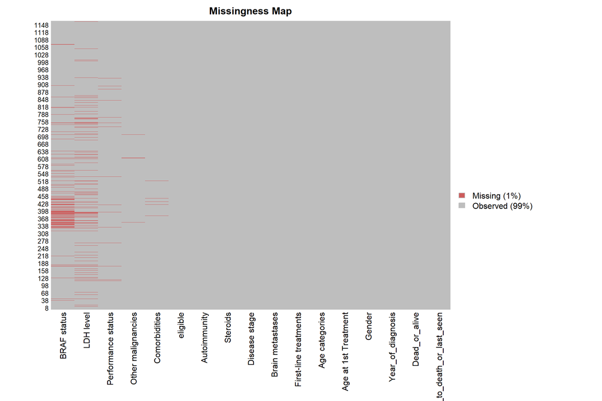

```r
missmap(dataDF, col=c("Indian red", "grey"), legend=TRUE,x.cex=1,margins=c(9,5))
```

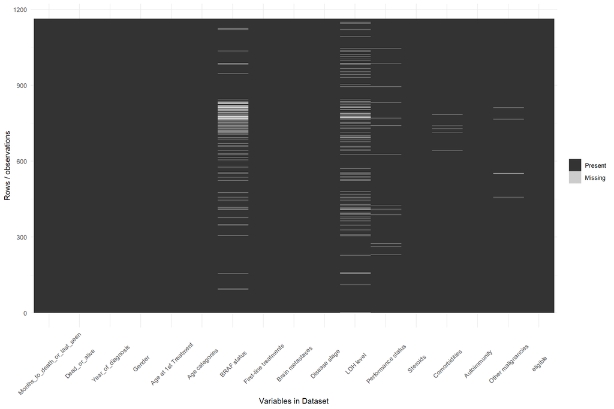

```r
ggplot_missing(dataDF)
```

# 3 Barplots

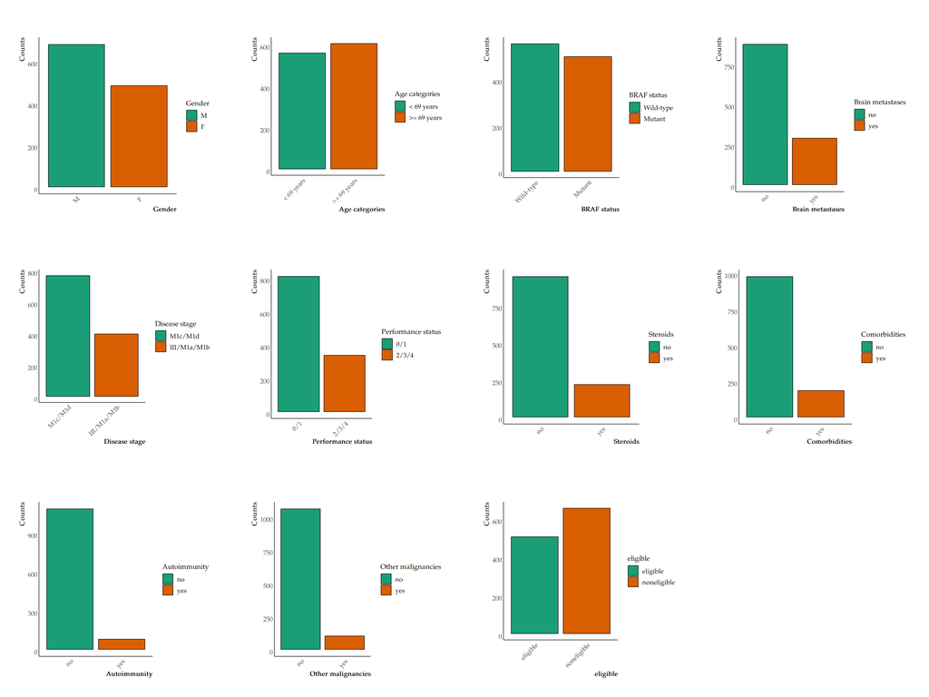

```r
barplots.nom<-lapply(categ_feats[-c(1,5,8)], function(x) barplot_nominal(dataDF,x,45,"Counts"))
# Calculate how many rows and columns I need
n<-length(barplots.nom);
graphCols <-ceiling(n/floor(sqrt(n)));
graphRows<-floor(sqrt(n))
ggarrange(plotlist = barplots.nom,nrow=graphRows, ncol=graphCols)
```

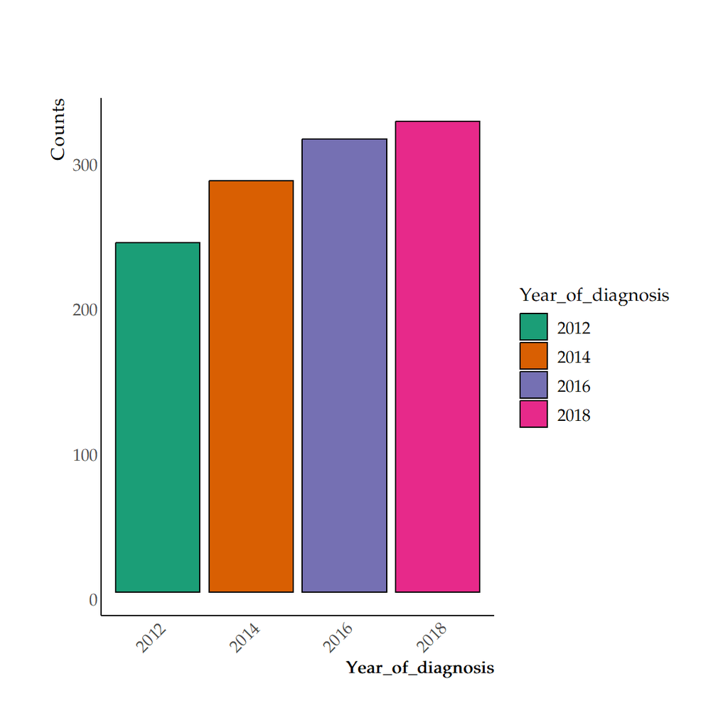

```r
barplot_nominal(dataDF,categ_feats[c(1)],45,"Counts")
```

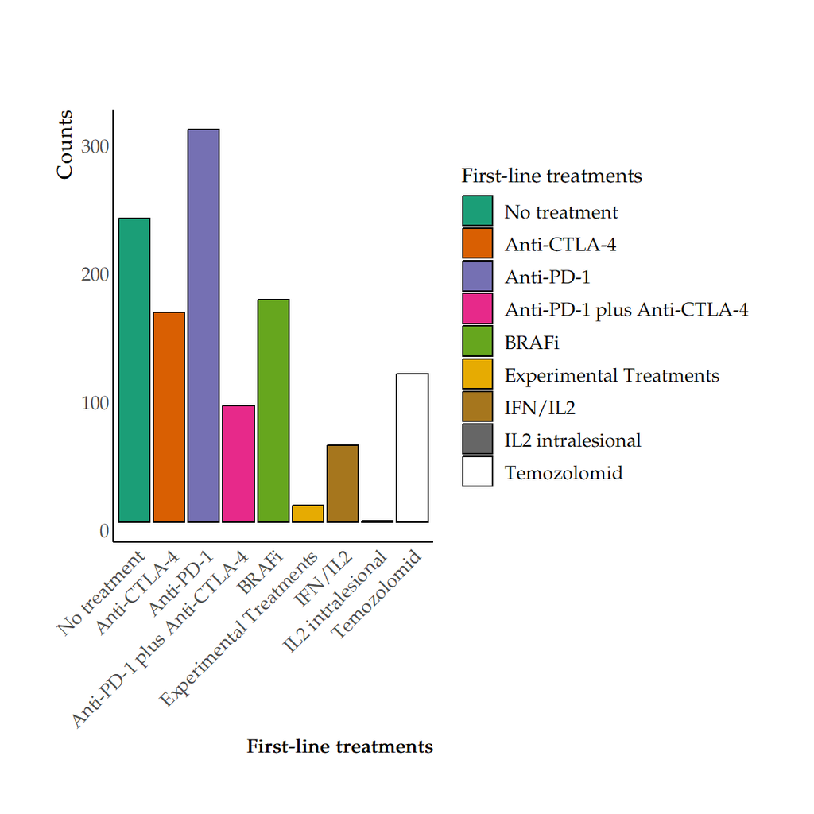

```r
barplot_nominal(dataDF,categ_feats[c(5)],45,"Counts")
```

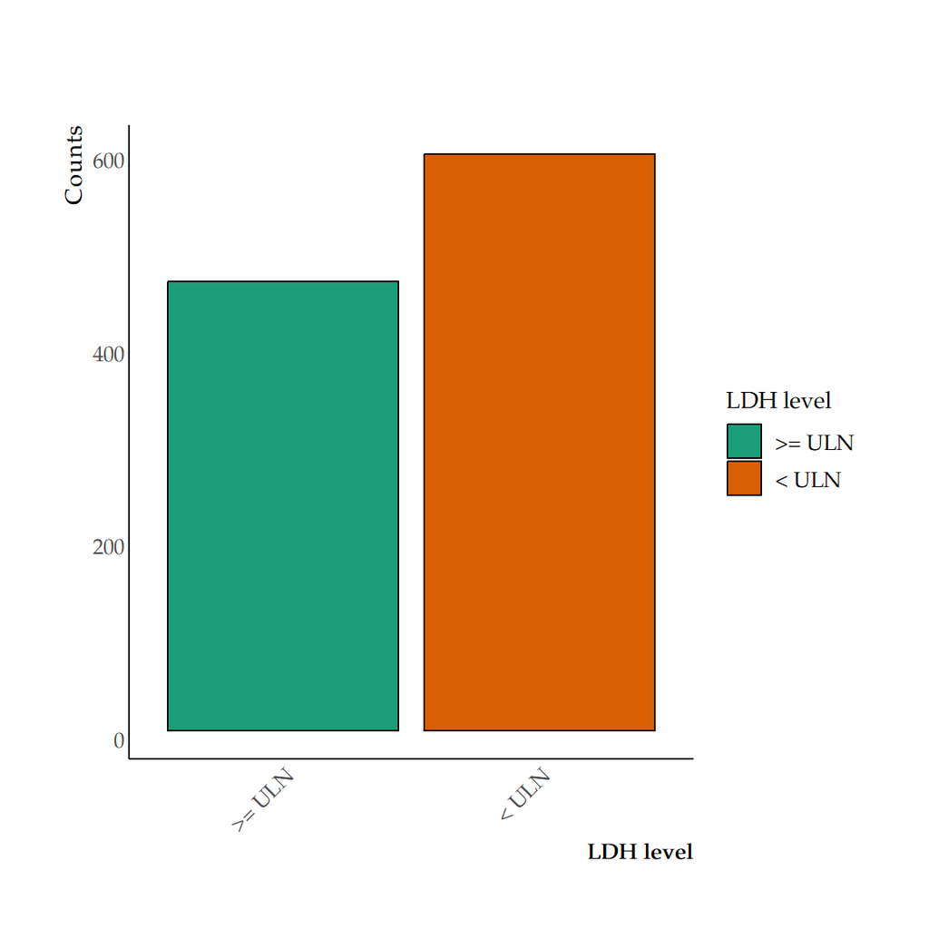

```r
barplot_nominal(dataDF,categ_feats[c(8)],45,"Counts")
```

# 4 Baseline Characteristics

## 4.1 Age

Here we want to see if baseline characteristics are similar across age groups.

We first make a new column, age group, divided as:per median

```r
age_thres <- median(dataDF$`Age at 1st Treatment`, na.rm = TRUE)
age_thres
```

```
## [1] 69.4
```

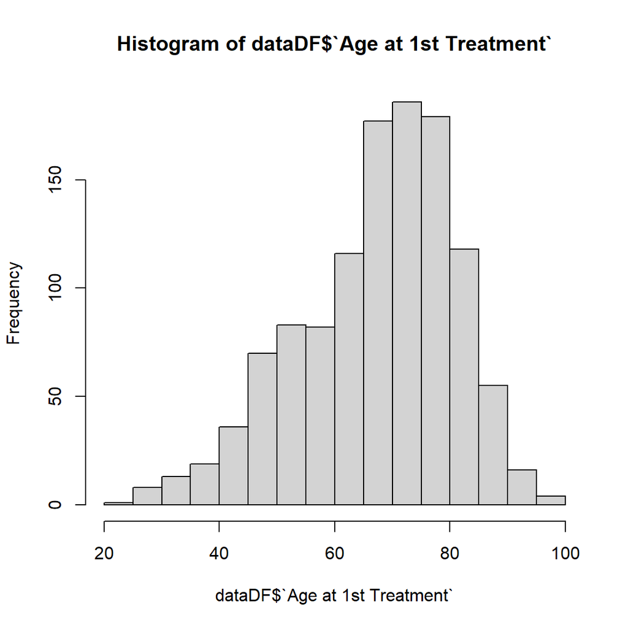

```r
hist(dataDF$`Age at 1st Treatment`)
```

```r
# age_cat <-dataDF %>% select(age) %>% dplyr::mutate(age_group = case_when(age >= age_thres ~ "old",
#                                         age < age_thres ~ "young",
#                                         TRUE~ as.character(age))) %>% pull(age_group)
#
#
# dataDF <- dataDF %>% add_column(age_group= factor(age_cat, levels=c("old","young")), .after ="age" )
```

```r
bars.age <-lapply(categ_feats[-c(1,3)], function(x) barplot_nominal_fac(dataDF,"Age categories",45,facetVariable = x))
```

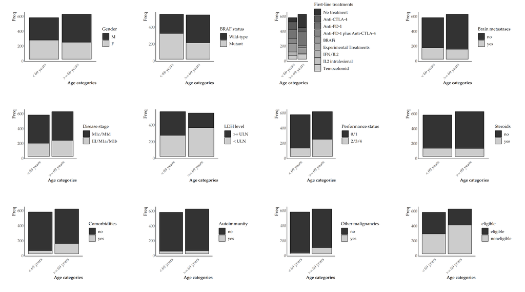

```r
n<-length(bars.age);
graphCols <-ceiling(n/floor(sqrt(n)));
graphRows<-floor(sqrt(n))
ggarrange(plotlist = bars.age,nrow=graphRows, ncol=graphCols)
```

## 4.2 Eligibility

Here we want to see if baseline characteristics are similar across eligibility groups.

```r
# barplot_nominal_fac(dataDF,"age_group",45,facetVariable = "gender")

bars.el<-lapply(c(categ_feats[c(1:13)]), function(x) barplot_nominal_fac(dataDF,"eligible",45,facetVariable = x))
```

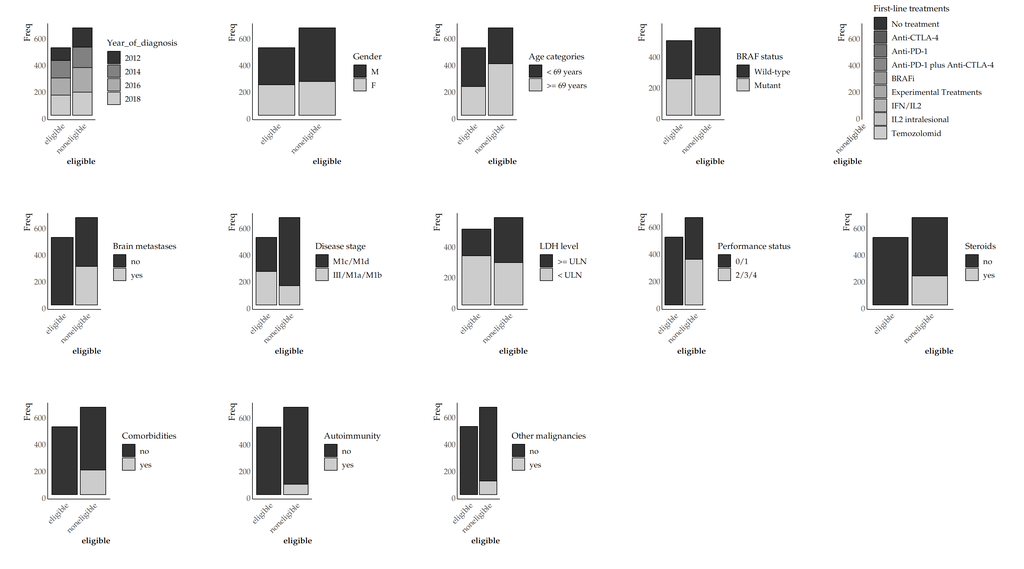

```r
n<-length(bars.el);
graphCols <-ceiling(n/floor(sqrt(n)));
graphRows<-floor(sqrt(n))
ggarrange(plotlist = bars.el,nrow=graphRows, ncol=graphCols)
```

```r
table(dataDF$eligible,dataDF$Year_of_diagnosis)
```

```
##
##               2012 2014 2016 2018
##   eligible      96  131  128  152
##   noneligible  145  153  185  173
```

# 5 Baseline characteristics of patients diagnosed in 2012,2014,2016 and 2018

```r
dataDF$eligible <- as.character(dataDF$eligible)
dataDF$eligible <- ifelse(dataDF$eligible=="eligible", "trial-like", "trial-excluded")
dataDF$eligible <- factor(dataDF$eligible, levels = c("trial-excluded", "trial-like"))
```

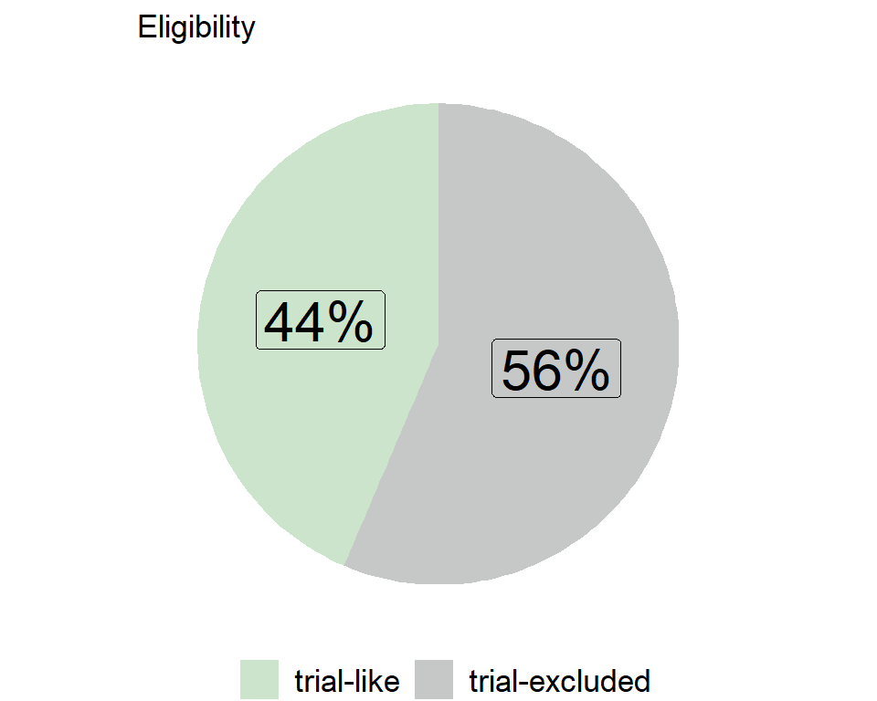

```r
dataDF$eligible <- relevel(dataDF$eligible, ref="trial-like")
myPieChart(dataDF, "eligible",filterVar=NULL,filterSel="Eligibility")
```

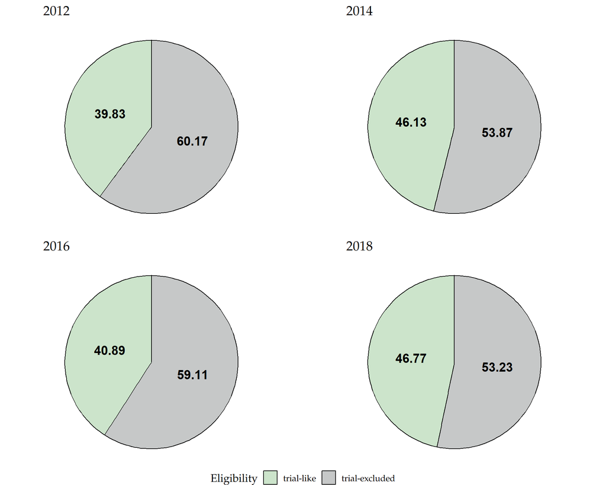

```r
pie.el<-lapply(levels(dataDF$Year_of_diagnosis), function(x) myPieChart2(dataDF, "eligible",filterVar="Year_of_diagnosis",filterSel=x, "Eligibility",fontSize = 0.87, fillPal = ccf_cols(c("surf_crest","silver_sand","ccf_green",  "maroon_flush")), repel=F
))

n<-length(pie.el);
graphCols <-ceiling(n/floor(sqrt(n)));
graphRows<-floor(sqrt(n))
ggarrange(plotlist = pie.el,nrow=graphRows, ncol=graphCols, common.legend = TRUE, legend = "bottom")
```